# Customer Service Requests Analysis

# Statistical test

### 1. Whether the average response time across complaint types is similar or not (overall)

- Since the test is all about comparing the averages across the group ANNOVA (Analysis of Variance) test is used
- We have one independent variable Resolution time between the groups and so One way ANNOVA would be used

#### Null Hypotheses

- The average response time across the complaint types are equal
- Ho: μ1=μ2=..=μn

#### Alternage Hypotheses

- The average response time across the complaint types are not equal
- H1: All μ are not equal

###### Test steps:

- We will determine the pvalue for the groups
- If the P value is less than alpha (0.05) we will reject null hypotheses
- If the P value is greater than alpha (0.05) we will accept the null hypotheses

```python
print("Totally we have {} number of compliants type".format(len(df_Customer_service_req['Complaint Type'].unique())))
```

```
Totally we have 24 number of compliants type
```

```python
df_Customer_service_req["Complaint Type"].value_counts()
```

```
Blocked Driveway             77044
Illegal Parking              75361
Noise - Street/Sidewalk      48612
Noise - Commercial           35577
Derelict Vehicle             17718
Noise - Vehicle              17083
Animal Abuse                  7778
Traffic                       4498
Homeless Encampment           4416
Noise - Park                  4042
Vending                       3802
Drinking                      1280
Noise - House of Worship       931
Posting Advertisement          650
Urinating in Public            592
Bike/Roller/Skate Chronic      427
Panhandling                    307
Disorderly Youth               286
Illegal Fireworks              168
Graffiti                       113
Agency Issues                    6
Squeegee                         4
Ferry Complaint                  2
Animal in a Park                 1
Name: Complaint Type, dtype: int64
```

- We have total of 24 Categories, however we can choose top 7 as others are less in count
- If these 7 groups average resolution time is same than mostly other small group too have the same
- If these 7 groups average resolution time is different than all other group will also have different average resolution time

```python
# Picking the top 7 compliant type
top_7_compliant_type=df_Customer_service_req["Complaint Type"].value_counts()[0:7].index
```

```python
#Converting the timedelta into minutes
df_Customer_service_req['Request_Closing_minutes']=df_Customer_service_req['Request_Closing_time'].values.astype('timedelta64[m]')+1
```

```python
# Creating a dummy list valiable to hold all data of 7 category
Resolution_time_for_each_complaint=[]
```

```python
# Conveting the date time delta vale to log so that we can tansform the data y=log(x) this will convert skewed data to approximately conform to normality.
for comp in top_7_compliant_type:
    Resolution_time_for_each_complaint.append(np.log(df_Customer_service_req[df_Customer_service_req['Complaint Type']==comp]['Request_Closing_minutes'].dropna().astype(np.int64)))
```

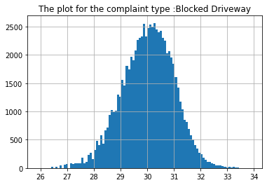

```python
Resolution_time_for_each_complaint[0].hist(bins=100)
plt_title="The plot for the complaint type :"+top_7_compliant_type[0]
plt.title(plt_title)
```

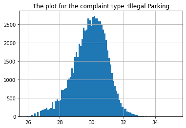

```python
Resolution_time_for_each_complaint[1].hist(bins=100)
plt_title="The plot for the complaint type :"+top_7_compliant_type[1]
plt.title(plt_title)
```

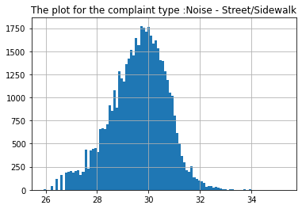

```python
Resolution_time_for_each_complaint[2].hist(bins=100)
plt_title="The plot for the complaint type :"+top_7_compliant_type[2]
plt.title(plt_title)
```

- Above plots confirmed that the data are normally distributed

```python
for c in range(0,len(Resolution_time_for_each_complaint)):
    print ("The standard deviation of complaint type {} is {}".format(top_7_compliant_type[c],Resolution_time_for_each_complaint[c].std()))
```

```
The standard deviation of complaint type Blocked Driveway is 0.9689925833875241
The standard deviation of complaint type Illegal Parking is 1.0676265933053914
The standard deviation of complaint type Noise - Street/Sidewalk is 1.088810766064205
The standard deviation of complaint type Noise - Commercial is 1.0751948896175374
The standard deviation of complaint type Derelict Vehicle is 1.2473713130448358
The standard deviation of complaint type Noise - Vehicle is 1.0640895098462981
The standard deviation of complaint type Animal Abuse is 1.0353212429125318
```

- The standard deviation of the compliant types are almost the same

```python
import scipy.stats as stats
```

```python
#Perfoming the annova test and getting the F and P value
fval,pval=stats.f_oneway(Resolution_time_for_each_complaint[0],Resolution_time_for_each_complaint[1]
                        ,Resolution_time_for_each_complaint[2],Resolution_time_for_each_complaint[3]
                         ,Resolution_time_for_each_complaint[4],Resolution_time_for_each_complaint[5]
                        ,Resolution_time_for_each_complaint[6])
```

```python
print("The F value is {} and the P value is {}".format(fval,pval))
```

```
The F value is 1771.494487912447 and the P value is 0.0
```

```python
if (pval<0.05):
    print('Null hypothesis is rejected since p value ({}) is less than 0.05'.format(np.around(pval,decimals=2)))
else:
    print('Null hypothesis is accepted since p value ({}) is greater than 0.05'.format(np.around(pval,decimals=2)))
```

```
Null hypothesis is rejected since p value (0.0) is less than 0.05
```

### Interpretation from the P value

- The p-value obtained from the Oneway ANNOVA is ~0.0 which is less than 0.05(alpha)
- With which we can determine with 95% confidence that the average resolution time of the different types of complaints are not same
- We have rejected the null hypothesis

## -------The average resolution time for the different type of compliants are not the same------

### 2. Are the type of complaints or service requested and location related?

- Identify the features that has type of complaints and location related details
- Since the relationship between variables are supposed to be indentified we need to perform the Statistical test related to the correlation
- Chi square test can be done for this case to test the relationship between multiple variables

#### Null Hypothesis

- Ho: There is no is that no relationship exists between the Service request type and location

#### Alternate Hypothesis

- H1 : There is significant relationship between the Service request type and location

```python
# Creating the Dataframe with complaint type and other location related data
location_cor_df=df_Customer_service_req[["Complaint Type","City","Borough","Latitude","Longitude"]]
```

```python
# Encoding the Copliant and City inorder to convert them into numeric value
from sklearn.preprocessing import LabelEncoder
label_encoder=LabelEncoder()
location_cor_df['Ed_comp_type']=label_encoder.fit_transform(location_cor_df['Complaint Type'])
location_cor_df['Ed_city']=label_encoder.fit_transform(location_cor_df['City'])
location_cor_df['Ed_Borough']=label_encoder.fit_transform(location_cor_df['Borough'])
```

```python
# The values seems to be negative and hence converting into positive
location_cor_df["Longitude"]=location_cor_df["Longitude"]*-1
```

```python
stat, p, dof, expected = stats.chi2_contingency(location_cor_df[["Ed_comp_type","Ed_city"]])
```

```python
print("The P-value is ",p)
```

```
The P-value is  0.0
```

```python
if (pval<0.05):
    print('Null hypothesis is rejected since p value ({}) is less than 0.05'.format(np.around(pval,decimals=2)))
else:
    print('Null hypothesis is accepted since p value ({}) is greater than 0.05'.format(np.around(pval,decimals=2)))
```

```
Null hypothesis is rejected since p value (0.0) is less than 0.05
```

### Interpretation from the P value

- The p-value obtained from the chi square test is ~0.0 which is less than 0.05(alpha)
- With which we can determine with 95% confidence that there is a significant relationship between the variables
- We have rejected the null hypothesis

## -------There is significant relationship between compliant type and the Location------